# Bacterial infection

# Setting up the R environment

### Installing packages and loading the library

```r
# Install packages
paket <- function(pak){
  new_pak <- pak[!(pak %in% rownames(installed.packages()))]
  if (length(new_pak))
    install.packages(new_pak, dependencies = TRUE,repos="https://cloud.r-project.org/")
  sapply(pak, library, character.only = TRUE)
}

listOfPackages <- c("tidyverse", "RColorBrewer", "knitr", "kableExtra", "tsModel", "gridExtra", "dplyr", "lubridate")
paket(listOfPackages)
```

### Plots aesthetics information

```r
# options(repr.plot.width = 18, repr.plot.height = 9)
theme_plots <- theme_bw() +
  theme(strip.text = element_text(size = 5),
        axis.text.x = element_text(size = 8),
        axis.text.y = element_text(size = 6),
        axis.title.x = element_text(size = 8),
        axis.title.y = element_text(size = 8),
        title = element_text(size = 10),
        plot.subtitle = element_text(size = 9, face = "italic"))
theme_set(theme_plots)

# Colorblind palette
cbPalette <- c("#999999", "#E69F00", "#56B4E9", "#009E73", "#F0E442", "#0072B2", "#D55E00", "#CC79A7")
```

# Data retrieval

## Variables that need to be checked/modified by each site

Change the values of the following variables according to the specificities of your site:

1. “folder_4ce_files”: folder path where your phase 2.2 data files are located
2. “obfuscation”: determine the obfuscation threshold (FALSE if no obfuscation, or the numeric value of the obfuscation threshold if any)
3. “dateFormat”: specify the format of the date at your site (e.g., for “03-AUG-20”, the format would be “%d-%b-%y”, [see documentation](https://www.stat.berkeley.edu/~s133/dates.html))
4. “data_update_date”: date at which the data has been updated in the local datawarehouse. Used to estimate patient age at time of visit, since patients age in the 4CE demographic file is expected the age at data update.
5. “time_period”: Time unit for the different graphs of the plots: months (default), weeks, days

```r
folder_4ce_files <- "/4ceData/Input/Phase2_AllAdm_March2022/"
obfuscation =  FALSE
#obfuscation = 3
dateFormat <- "%d-%b-%y"
min_hosp_days <- 1
data_update_date <- "2022-04-02"
time_period <-"months" #possible values: days, weeks, months
```

```r
# cut-off dates used in the analysis, these should not be changed
pandemic_start_date <- as.Date("2020-03-15")
start_date_plots <- as.Date("2018-12-01")
end_date_plots <- as.Date("2023-01-01")
```

## Data loading

We will use as input the 2.2 data files. Specifically: - LocalPatientSummary - LocalPatientObservation - LocalPatientClinicalcourse

### Reading 4CE phase 2.2 files

```r
### Read the CSV input files
source("R/readInputFiles.R")

getwd()
```

```
## [1] "/4ceData/Phase2.2BacterialInfection"
```

```r
files <- readInputFiles( path      = folder_4ce_files,
                         separator = ",",
                         skip      = 0,
                         verbose   = FALSE )

## Create the output folder if it doesn't exist
if (! "output" %in% list.dirs()) dir.create("output")

### Extract the patient summary and observation information.
demo_raw <- files[["patientSummary"]] %>% filter(cohort == "AllAdm")
obs_raw <- files[["patientObservations"]] %>% filter(cohort == "AllAdm")
clinical_raw <- files[["patientClinicalCourse"]] %>% filter(cohort == "AllAdm")
```

### Select the specific ICD codes of interest

```r
#### ICD codes bacterial conditions ####
icdCodes <- read.csv("public-data/ICD_bacterial4.csv", header = TRUE, colClasses = "character") %>%
   dplyr::select( disorder_group = syndrome, ICD10_Code, description, bacterial_syndrome )
```

## Data-management

### Filtering on “inpatient” status

```r
# Filtering on inpatients here (in_hospital == 1), to reduce subsequent compute time of the encounter length calculation
clinical_raw <- filter(clinical_raw, in_hospital == 1)
```

### Calculating duration of individual hospitalizations

Adding columns with hospitalization number and hospitalization length to the clinical raw file

```r
count_sequences_hospitalisation <- function(df, ...) {
  seq_hospitalisation_df <- data.frame(total_span = seq(min(df$days_since_admission),
                                                        max(df$days_since_admission))
  ) %>%
    left_join(df, by = c("total_span" = "days_since_admission")) %>%
    replace_na(list(in_hospital = 0))
  count_sequences <- rle(seq_hospitalisation_df$in_hospital)
  count_sequences_1 <- lapply(count_sequences, function(x) x[count_sequences$values == 1])
  n_sequences <- seq_along(count_sequences_1$lengths)
  sequences <- rep.int(n_sequences, count_sequences_1$lengths)
  sequences_len <- rep.int(count_sequences_1$lengths, count_sequences_1$lengths)
  stopifnot(length(df$days_since_admission) == length(sequences))
  data.frame(days_since_admission = df$days_since_admission,
             n_hospitalisation = sequences,
             len_hospitalisation = sequences_len)
}
stopifnot(all(clinical_raw$in_hospital == 1))
hospitalisations_seq_df <- clinical_raw %>%
  distinct(patient_num, cohort, days_since_admission, in_hospital) %>%
  group_by(patient_num, cohort) %>%
  group_modify(count_sequences_hospitalisation)

clinical_raw <- left_join(clinical_raw,
                          hospitalisations_seq_df,
                          by = c("patient_num", "cohort", "days_since_admission"))
```

### Counting ICD10 bacterial infection codes in the obs_raw table

```r
### check that the ICD codes follow the regular expression [A-Z][0-9][0-9AB]\.?[0-9A-TV-Z]{0,4}
codesToReview <- obs_raw %>% dplyr::filter(concept_type == "DIAG-ICD10",
                                           ! grepl( "[A-Z][0-9][0-9AB]\\.?[0-9A-TV-Z]{0,4}", concept_code))
print(codesToReview)
```

```
##   siteid cohort patient_num days_since_admission concept_type concept_code
## 1    BCH AllAdm     1745440                  105   DIAG-ICD10          FDX
##   value
## 1  -999
```

```r
### Remove dots from the input file
icdCodes$concept_code <- gsub("\\.", "", icdCodes$ICD10_Code)

### Calculate how many of the bacterial infection codes are in the dataset
bacterialInfectionCodes <- unique( obs_raw %>%
  dplyr::mutate( concept_code = gsub("[.]", "", concept_code ) ) %>%
  dplyr::filter( concept_type == "DIAG-ICD10",
                 concept_code %in% icdCodes$concept_code ) %>%
  dplyr::mutate( concept_code = as.character( concept_code ),
                 concept_length = nchar( concept_code ),
                 concept_check = ifelse( concept_length == 2 | concept_length > 8, "Check", "OK")) %>%
  dplyr::select( concept_code, concept_length, concept_check) )

summary(as.factor( bacterialInfectionCodes$concept_check ) )
```

```
##  OK
## 328
```

```r
print( paste0("There are ", length(bacterialInfectionCodes$concept_code), " ICD10 bacterial infection codes out of the total ",length(unique(icdCodes$ICD10_Code)), " in the dataset"))
```

```
## [1] "There are 328 ICD10 bacterial infection codes out of the total 653 in the dataset"
```

### Calculating age at hospitalization time

```r
# Calculating patient age at the time of visit, assuming the age used is the patients' age at the time of extraction (last discharge date available in the data)
obs_raw_age <- left_join(obs_raw, demo_raw[c("patient_num", "age")], by = c("patient_num")) %>%
  inner_join(clinical_raw[, c("patient_num", "days_since_admission", "calendar_date")],
            by = c("patient_num", "days_since_admission"))
obs_raw_age$age_time_diagnosis <- obs_raw_age$age - floor(as.numeric(as.Date(data_update_date) - as.Date(obs_raw_age$calendar_date, dateFormat)) / 365.25)
```

### Applying inclusion criteria to filter and format the data

We are selecting hospitalizations based on the following criteria:

```r
obs_filtered_age <- obs_raw_age %>%
  filter(concept_type == 'DIAG-ICD10',
         days_since_admission >= 0)

clinical_filtered <- clinical_raw %>%
  filter( len_hospitalisation >= min_hosp_days,
          cohort  %in% c("AllAdm")) %>%
  dplyr::mutate( date = as.Date( calendar_date, format = dateFormat ),
                 weeks = as.Date(cut( date, breaks = "week")),
                 month = as.Date(cut( date, breaks = "month")),
                 year = format( date, "%Y"),
                 period = ifelse( date < pandemic_start_date,
                                  "before_pandemic", "during_pandemic"))

if( time_period == "weeks"){
  clinical_filtered$time_p <- clinical_filtered$weeks
}else if(time_period == "days"){
  clinical_filtered$time_p <- clinical_filtered$date
}else if(time_period == "months"){
  clinical_filtered$time_p <- clinical_filtered$month
}
```

```r
# Steps necessary to filter rows:
  # - encounters without ICD
  # - ICD diagnosed outside of encounters
  # - patients from the patients table that don't have any encounters matching the criteria
clinical_table <- clinical_filtered %>%
  inner_join( distinct(obs_filtered_age, patient_num, days_since_admission),  by = c("patient_num", "days_since_admission")) %>%
  distinct(patient_num, n_hospitalisation) %>%
  inner_join(clinical_filtered, by = c("patient_num", "n_hospitalisation"))
# Adding new columns
observation_table <- obs_filtered_age %>%
  inner_join(clinical_table[, c("patient_num", "days_since_admission")], by = c("patient_num", "days_since_admission"))
demographic_table <- demo_raw %>%
  inner_join(distinct(clinical_table, patient_num), by = "patient_num")
all_codes <- observation_table %>%
   inner_join(select(clinical_table, -calendar_date), by = c("patient_num", "days_since_admission")) %>%
   inner_join(demographic_table[, c("patient_num", "sex")], by = "patient_num")
```

```r
stopifnot(unique(all_codes$cohort) == "AllAdm")
stopifnot(unique(all_codes$in_hospital) == 1)
stopifnot(unique(all_codes$len_hospitalisation >= min_hosp_days))
stopifnot(nrow(all_codes) == nrow(observation_table))
stopifnot(length(unique(all_codes$patient_num)) == length(unique(demographic_table$patient_num)))
stopifnot(length(unique(all_codes$patient_num)) == length(unique(observation_table$patient_num)))
stopifnot(length(unique(all_codes$patient_num)) == length(unique(clinical_table$patient_num)))
stopifnot(nrow(distinct(all_codes, patient_num, n_hospitalisation)) == nrow(distinct(clinical_table, patient_num, n_hospitalisation)))
stopifnot(nrow(distinct(all_codes, patient_num, days_since_admission)) == nrow(distinct(observation_table, patient_num, days_since_admission)))
```

### Filtering on age less than 18

```r
# Filtering hospitalizations where patient age is in inclusion criteria
observation_table_ado <- filter(observation_table, age_time_diagnosis < 18)

# Filtering observation tables which patient_num and days_since_admission are still in clinical table after filtering on age

clinical_test <- clinical_table[, c("patient_num", "n_hospitalisation", "days_since_admission")] %>%
  inner_join(distinct(observation_table_ado, patient_num, days_since_admission, age_time_diagnosis),
            by = c("patient_num", "days_since_admission")) %>%
  distinct(patient_num, n_hospitalisation, age_time_diagnosis)

clinical_table_ado <- clinical_table %>%
  inner_join(clinical_test,
             by = c("patient_num", "n_hospitalisation"))

# Filtering observation tables which patient_num are still in clinical table after filtering on age
demographic_table_ado <- demographic_table %>%
  inner_join(distinct(clinical_table_ado, patient_num), by = "patient_num")

all_codes_ado <- all_codes %>%
   filter(age_time_diagnosis <  18)
```

```r
stopifnot(unique(all_codes_ado$cohort) == "AllAdm")
stopifnot(unique(all_codes_ado$in_hospital) == 1)
stopifnot(unique(all_codes_ado$len_hospitalisation >= min_hosp_days))
stopifnot(nrow(all_codes_ado) == nrow(observation_table_ado))
stopifnot(length(unique(all_codes_ado$patient_num)) == length(unique(demographic_table_ado$patient_num)))
stopifnot(length(unique(all_codes_ado$patient_num)) == length(unique(observation_table_ado$patient_num)))
stopifnot(length(unique(all_codes_ado$patient_num)) == length(unique(clinical_table_ado$patient_num)))
stopifnot(nrow(distinct(all_codes_ado, patient_num, n_hospitalisation)) == nrow(distinct(clinical_table_ado, patient_num, n_hospitalisation)))
stopifnot(nrow(distinct(all_codes_ado, patient_num, days_since_admission)) == nrow(distinct(observation_table_ado, patient_num, days_since_admission)))
```

#### QC step: do a summary of the bacterial infection ICD codes present in each site

As output we will generate a table with: the number of observations per code, number of patients diagnosed with each code and the date range in which the code was used.

```r
#filter the whole dataset to only mental codes
bacteria_infection_codes_qc <- all_codes_ado %>%
  mutate( concept_code = gsub("[.]", "", concept_code)) %>%
  filter( concept_code %in% bacterialInfectionCodes$concept_code )

bacteria_infection_codes_qc_output <- bacteria_infection_codes_qc %>%
  group_by( concept_code ) %>%
  dplyr::summarise( distinct_patients = ifelse(length(unique(patient_num)) > obfuscation | isFALSE(obfuscation),
                               length(unique(patient_num)),
                               0.5),
                    distinct_observations = ifelse(length(patient_num) > obfuscation | isFALSE(obfuscation),
                               length(patient_num),
                               0.5),
                    min_date = min( dmy( calendar_date ) ),
                    max_date = max( dmy( calendar_date ) ))%>%
  arrange(desc(distinct_observations))

bacteria_infection_codes_qc_output <- bacteria_infection_codes_qc_output %>%
  left_join( icdCodes, by="concept_code")  %>%
  select( "disorder_group", "description", "concept_code", "distinct_patients",
          "distinct_observations", "min_date", "max_date")

bacteria_infection_codes_qc_output[1:10, ]
```

```
## # A tibble: 10 × 7
##    disorder_group      description conce…¹ disti…² disti…³ min_date   max_date
##    <chr>               <chr>       <chr>     <int>   <int> <date>     <date>
##  1 UTI/pyelonefritis   Urinary tr… N390        780    1257 2019-01-02 2021-09-17
##  2 sepsis              Sepsis, un… A419        557     705 2019-01-01 2021-09-13
##  3 sepsis              …… with se… R6521       307     430 2019-01-02 2021-09-17
##  4 skin infections     Cellulitis… L0390       278     350 2019-01-03 2021-09-14
##  5 bacterial enteritis …… not spe… A0472       202     320 2019-01-11 2021-08-29
##  6 UTI/pyelonefritis   Acute tubu… N10         224     287 2019-01-07 2021-09-17
##  7 bacterial pneumonia Unspecifie… J159        254     276 2019-01-03 2021-09-05
##  8 bacterial pneumonia Klebsiella… B961        202     258 2019-01-08 2021-09-03
##  9 bone infections     Osteomyeli… M869        147     211 2019-01-03 2021-09-15
## 10 skin infections     Cellulitis… L03311      153     207 2019-01-09 2021-09-13
## # … with abbreviated variable names ¹concept_code, ²distinct_patients,
## #   ³distinct_observations
```

```r
### counts per disorder group and year
bacteria_infection_codes_qc %>%
  left_join( icdCodes ) %>%
  group_by( disorder_group, year ) %>%
  dplyr::summarise( distinct_patients = ifelse(length(unique(patient_num)) > obfuscation | isFALSE(obfuscation),
                               length(unique(patient_num)),
                               0.5),
                    distinct_observations = ifelse(length(patient_num) > obfuscation | isFALSE(obfuscation),
                               length(patient_num),
                               0.5),
                    min_date = min( dmy( calendar_date ) ),
                    max_date = max( dmy( calendar_date ) ))%>%
  arrange(disorder_group, year )
```

```
## # A tibble: 33 × 6
## # Groups:   disorder_group [11]
##    disorder_group       year  distinct_patients distinct…¹ min_date   max_date
##    <chr>                <chr>             <int>      <int> <date>     <date>
##  1 bacterial enteritis  2019                166        258 2019-01-07 2019-12-30
##  2 bacterial enteritis  2020                169        277 2020-01-01 2020-12-30
##  3 bacterial enteritis  2021                111        173 2021-01-01 2021-09-17
##  4 bacterial meningitis 2019                 43         69 2019-01-01 2019-12-31
##  5 bacterial meningitis 2020                 45         96 2020-01-01 2020-12-31
##  6 bacterial meningitis 2021                 18         28 2021-01-14 2021-08-07
##  7 bacterial pneumonia  2019                339        441 2019-01-02 2019-12-31
##  8 bacterial pneumonia  2020                253        368 2020-01-01 2020-12-31
##  9 bacterial pneumonia  2021                101        131 2021-01-04 2021-09-14
## 10 bone infections      2019                113        466 2019-01-03 2019-12-22
## # … with 23 more rows, and abbreviated variable name ¹distinct_observations
## # ℹ Use `print(n = ...)` to see more rows
```

### Add the bacterial infection ICD code description and filter

```r
# Getting site name, will be used later in the analysis
site <- unique(as.character(demo_raw$siteid))


all_codes_desc <- all_codes_ado %>%
  mutate( concept_code = gsub("[.]", "", concept_code)) %>%
  left_join( icdCodes, by=c("concept_code") ) %>%
  mutate(icd_code_category = ifelse(concept_code %in% icdCodes$concept_code,
                               "bacterial",
                               "others")) %>%
  dplyr::select( patient_num, sex, age_time_diagnosis, concept_type, concept_code, calendar_date,
                 in_hospital, n_hospitalisation, len_hospitalisation, date, weeks, month, year,
                 period, time_p, disorder_group, description, icd_code_category )

all_codes_bacterial <- all_codes_desc %>%
  filter(concept_code %in% icdCodes$concept_code)
```

# Results

## Admission

First calculation: total number of patients, matching the inclusion criteria, admitted on one day (without filtering by any disease subtype). Summed up over one week, or one month depending on the time unit chosen. Not filtered on qge.

```r
admission_plot_count <- function(df,
                               x,
                               y,
                               title,
                               y_title,
                               size = NULL,
                               color = NULL){
  plot <- ggplot(df, aes_string(x = x, y = y, color = color, size = size))  +
    geom_point() +
    scale_x_date(date_breaks = "1 month", date_labels =  "%b %Y", limits = c(start_date_plots, end_date_plots), expand = expansion(mult = 0.01, add = 1)) +
    theme(axis.text.x=element_text(angle=60, hjust=1))+
    labs(x = "Calendar date",
         y = y_title,
       title = title)
  return(plot)
}
```

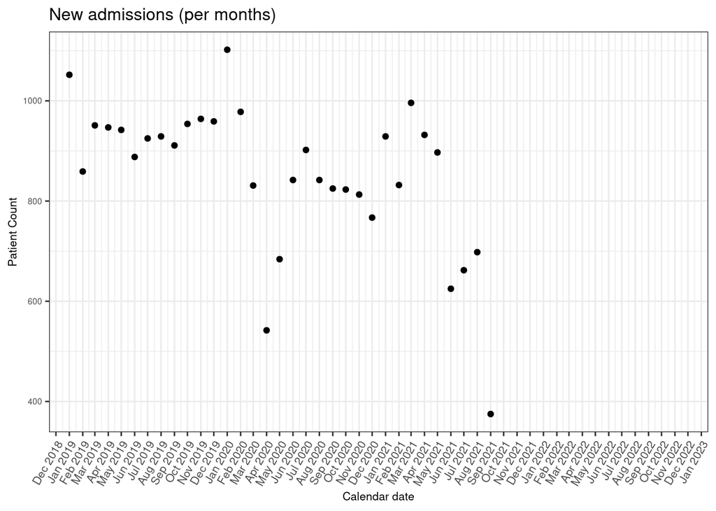

```r
new_hospitalizations <- clinical_table %>%
  group_by(patient_num, n_hospitalisation) %>%
  slice(which.min(time_p)) %>%
  filter( in_hospital == 1 ) %>%
    group_by( time_p ) %>%
  summarise(count = ifelse(n_distinct(patient_num) > obfuscation | isFALSE(obfuscation),
                               n_distinct(patient_num),
                               0.5)) %>%
  ungroup()

nh <- admission_plot_count(df = new_hospitalizations,
                     x = "time_p",
                     y = "count",
                     title = paste0("New admissions (per ", time_period,")"),
                     y_title = "Patient Count")

nh
```

## New admissions age range 0-17

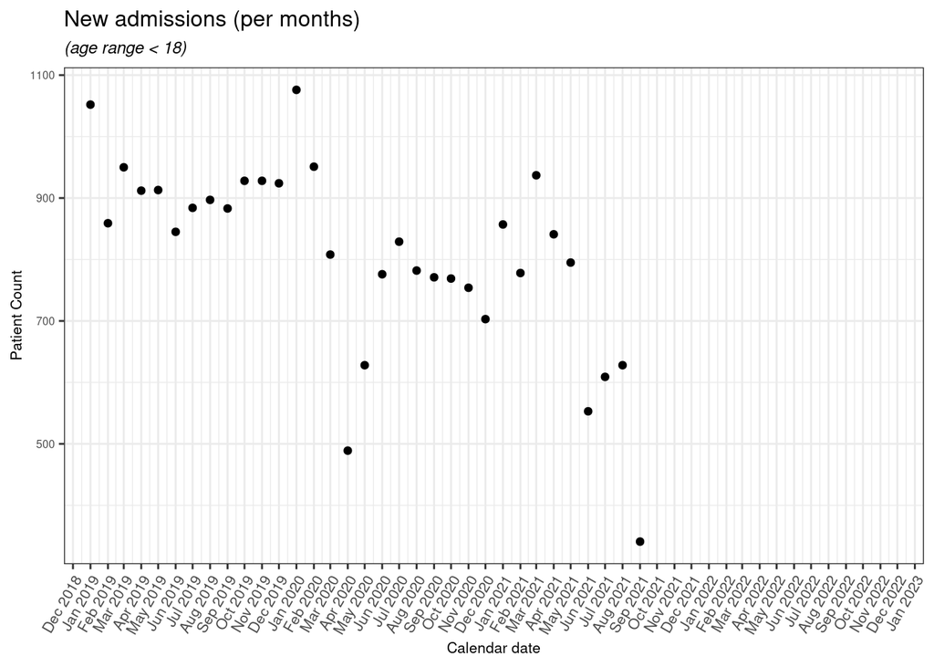

```r
new_hospitalizations_ado <- clinical_table_ado %>%
  group_by(patient_num, n_hospitalisation) %>%
  slice(which.min(time_p)) %>%
  filter( in_hospital == 1 ) %>%
    group_by( time_p ) %>%
  summarise(count = ifelse(n_distinct(patient_num) > obfuscation | isFALSE(obfuscation),
                               n_distinct(patient_num),
                               0.5)) %>%
  ungroup()


nh_ado <- admission_plot_count(df = new_hospitalizations_ado,
                     x = "time_p",
                     y = "count",
                     title = paste0("New admissions (per ", time_period, ")"),
                     y_title = "Patient Count")+
    labs( subtitle = "(age range < 18)")

nh_ado
```

## Total hospitalize patients age range < 18

Calculating the total number of patients hospitalized on a given day (taking into account the hospitalization length).

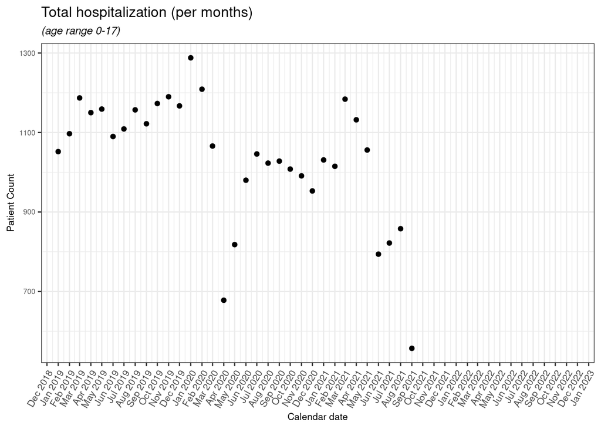

```r
unique_patients_hospitalized <- clinical_table_ado %>%
  filter(date < end_date_plots &
         date >= start_date_plots ) %>%
    group_by( time_p ) %>%
  summarise(count = ifelse(n_distinct(patient_num) > obfuscation | isFALSE(obfuscation),
                               n_distinct(patient_num),
                               0.5))

th <- admission_plot_count(df = unique_patients_hospitalized,
                     x = "time_p",
                     y = "count",
                     title = paste0("Total hospitalization (per ", time_period, ")"),
                     y_title = "Patient Count") +
  labs( subtitle = "(age range 0-17)")
th
```

## Patient count filtered on bacterial infection disorders

### New admissions

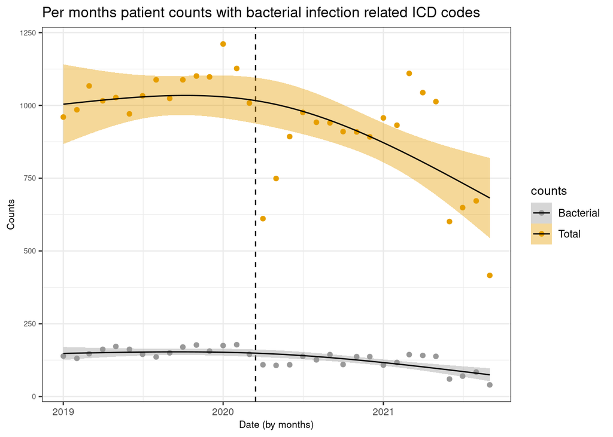

```r
count_icd_bacterial <- all_codes_bacterial %>%
  filter(date < end_date_plots &
         date >= start_date_plots ) %>%
    group_by( time_p ) %>%
  summarise(count_bacterial =  ifelse(n_distinct(patient_num) > obfuscation | isFALSE(obfuscation),
                               n_distinct(patient_num),
                               0.5)) %>%
  mutate( period = ifelse( time_p < pandemic_start_date,
                           "before_pandemic",
                           "during_pandemic")
  )

count_icd <- all_codes_desc %>%
  filter(date < end_date_plots &
         date >= start_date_plots ) %>%
    group_by( time_p ) %>%
  summarise(count_icd =  ifelse(n_distinct(patient_num) > obfuscation | isFALSE(obfuscation),
                               n_distinct(patient_num),
                               0.5)) %>%
  mutate( period = ifelse( time_p < pandemic_start_date,
                           "before_pandemic",
                           "during_pandemic")
  )

count_icd <- count_icd %>%
  left_join(count_icd_bacterial,
            by = c("time_p", "period")) %>%
  replace_na(list(count_bacterial = 0))

count_icd$percentage_bacterial <- 100*count_icd$count_bacterial / count_icd$count_icd


thpd_bacterialCount <- count_icd %>%
  pivot_longer(names_to = "counts", cols=c(count_bacterial, count_icd)) %>%
  mutate( counts = ifelse( counts == "count_bacterial", "Bacterial", "Total")) %>%
  ggplot(aes(x = time_p, y = value, fill = counts, color = counts)) +
  geom_point() +
  geom_vline(xintercept = as.Date(pandemic_start_date),
             linetype = "dashed") +
  scale_fill_manual(values = cbPalette) +
  scale_color_manual(values = cbPalette) +
  labs(y = "Counts",
       x = paste0("Date (by ", time_period,")"),
       title = paste0("Per ", time_period , " patient counts with bacterial infection related ICD codes")) +
  geom_smooth(method = "lm", formula = y ~ splines::ns(x, 2), se = TRUE, aes(colour=period), colour= "black", size = 0.5)

thpd_bacterialCount
```

### Ratio: patients with bacterial infection condition / patients without bacterial infection condition

```r
all_patients <- unique( all_codes_desc[, c("patient_num", "time_p")])
patients_with_bacterial_conditions <- unique( all_codes_bacterial[, c("patient_num", "time_p")] )
patients_without_bacterial_conditions <- setdiff(all_patients,patients_with_bacterial_conditions)

patients_without_bacterial_conditions_counts <- patients_without_bacterial_conditions %>%
  group_by( time_p ) %>%
  summarise(count_no_bacterial_patients =  ifelse(n_distinct(patient_num) > obfuscation | isFALSE(obfuscation),
                               n_distinct(patient_num),
                               0.5)) %>%
  mutate( period = ifelse( time_p < pandemic_start_date,
                           "before_pandemic",
                           "during_pandemic"))


patients_with_bacterial_conditions_counts <-  patients_with_bacterial_conditions %>%
  group_by( time_p ) %>%
  summarise(count_bacterial_patients =  ifelse(n_distinct(patient_num) > obfuscation | isFALSE(obfuscation),
                               n_distinct(patient_num),
                               0.5)) %>%
  mutate( period = ifelse( time_p < pandemic_start_date,
                           "before_pandemic",
                           "during_pandemic"))

ratios_patients_with_without_bacterial <- patients_without_bacterial_conditions_counts %>%
  full_join( patients_with_bacterial_conditions_counts, by=c("time_p", "period")) %>%
  mutate( ratio = count_bacterial_patients/count_no_bacterial_patients,
          percentage = 100 * count_bacterial_patients/(count_no_bacterial_patients + count_bacterial_patients))
```

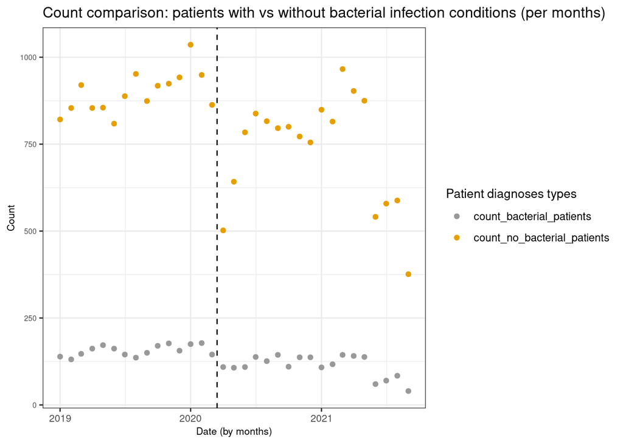

```r
ratios_patients_with_without_bacterial %>%
  pivot_longer(cols = c("count_no_bacterial_patients", "count_bacterial_patients"),
               values_to = "count",
               names_to = "count_type") %>%
  ggplot(aes(x = time_p, y = count, color = count_type)) +
  geom_point() +
  geom_vline(xintercept = as.Date(pandemic_start_date),
             linetype = "dashed") +
  scale_fill_manual(values = cbPalette) +
  scale_color_manual(values = cbPalette) +
  labs(y = "Count",
       x = paste0("Date (by ", time_period,")"),
       title = paste0("Count comparison: patients with vs without bacterial infection conditions (per ", time_period,")")) +
  guides(color = guide_legend(title="Patient diagnoses types"))
```

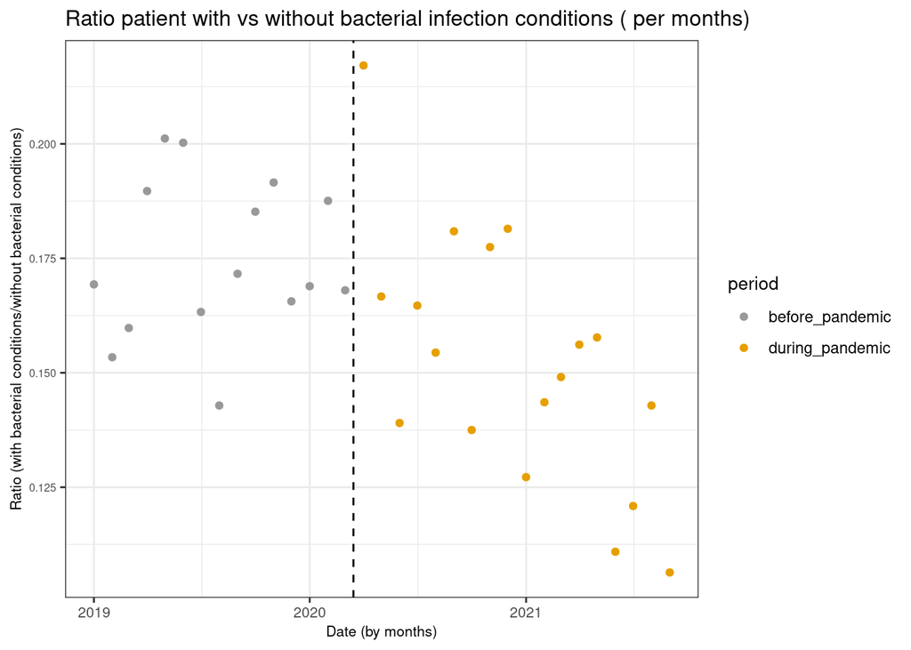

```r
ratio_bacterial_non_bacterial <- ratios_patients_with_without_bacterial %>%
  ggplot(aes(x = time_p, y = ratio, fill = period, color = period)) +
  geom_point() +
  geom_vline(xintercept = as.Date(pandemic_start_date),
             linetype = "dashed") +
  scale_fill_manual(values = cbPalette) +
  scale_color_manual(values = cbPalette) +
  labs(y = "Ratio (with bacterial conditions/without bacterial conditions)",
       x = paste0("Date (by ", time_period,")"),
       title = paste0("Ratio patient with vs without bacterial infection conditions ( per ", time_period,")"))

ratio_bacterial_non_bacterial
```

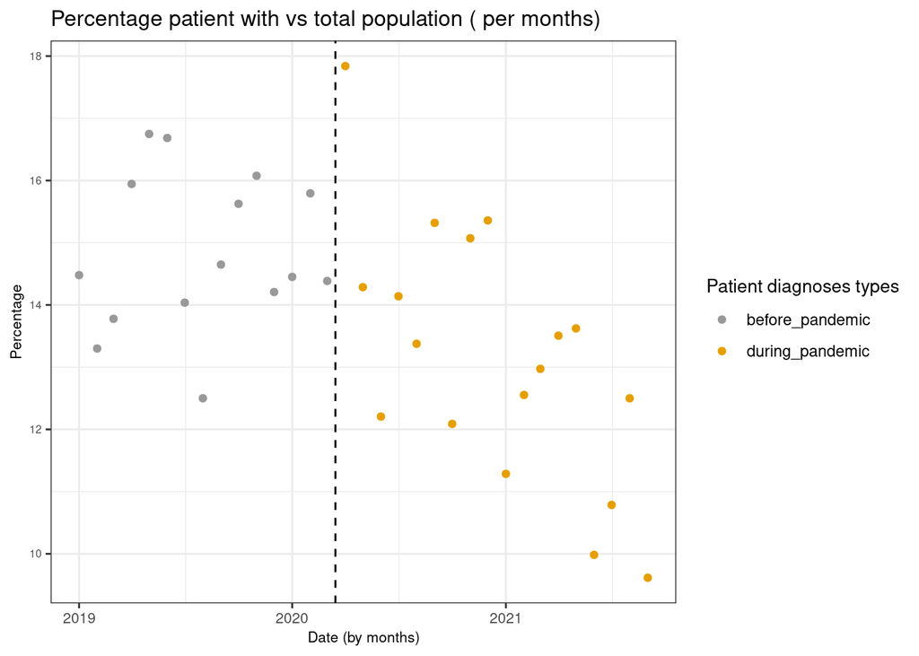

```r
ratios_patients_with_without_bacterial %>%
  ggplot(aes(x = time_p, y = percentage, color = period)) +
  geom_point() +
  geom_vline(xintercept = as.Date(pandemic_start_date),
             linetype = "dashed") +
  scale_fill_manual(values = cbPalette) +
  scale_color_manual(values = cbPalette) +
  labs(y = "Percentage",
       x = paste0("Date (by ", time_period,")"),
       title = paste0("Percentage patient with vs total population ( per ", time_period,")")) +
  guides(color = guide_legend(title="Patient diagnoses types"))
```

## Interrupted Time-Series Analyses

```r
# Model without seasonality
time_series_analysis_plotting <- function(model, df_count_bacterial, count_col, clearance_period = FALSE) {
  output_model <- broom::tidy(model)
  coeff_slope <- round(output_model[output_model$term == "periodduring_pandemic:time", "estimate"][[1]], 3)
  pvalue_slope <- round(output_model[output_model$term == "periodduring_pandemic:time", "p.value"][[1]], 3)
  annotation <- paste0("Lockdown slope: ", coeff_slope, " (pvalue: ", pvalue_slope, ")")
  pred_model <- predict(model, df_count_bacterial, type = "response", interval = "confidence") %>% as.data.frame()
  pred_model_b <- predict(model, mutate(df_count_bacterial, period = "before_pandemic"), type = "response", interval = "confidence") %>%
    as.data.frame()
  names(pred_model_b) <- paste0(names(pred_model_b), "_wo_intervention")
  pred_model <- bind_cols(df_count_bacterial, pred_model, pred_model_b)
  if (clearance_period) {
    pred_model$clearance_period <- ifelse(pred_model$time_p < as.Date(cut(start_clear_period, breaks = time_period)) ,
                                          "before_pandemic",
                                          ifelse(pred_model$time_p > as.Date(cut(end_clear_period, breaks = time_period)),
                                                 "during_pandemic",
                                                 "during_clearance")
    )
    pred_model$lwr <- ifelse(pred_model$clearance_period == "during_clearance", NA, pred_model$lwr)
    pred_model$upr <- ifelse(pred_model$clearance_period == "during_clearance", NA, pred_model$upr)
    pred_model$fit_wo_intervention <- ifelse(pred_model$time_p >= max(pred_model$time_p[pred_model$clearance_period == "before pandemic"]),
                                             pred_model$fit_wo_intervention,
                                             NA)
  } else {
    pred_model$clearance_period <- pred_model$period
  }
  plot <- ggplot(pred_model, aes_string(x = "time_p", y = count_col)) +
    geom_point(aes(colour = clearance_period)) +
    geom_line(aes(x = time_p, y = fit_wo_intervention, colour = "Expected mean w/o pandemic"), linetype = "dashed") +
    geom_line(aes(x = time_p, y = fit, colour = clearance_period)) +
    geom_ribbon(aes(ymin = lwr, ymax = upr, colour = clearance_period), alpha = 0.3, colour = NA) +
    scale_color_manual(name = "Time Series projection", values = c("before_pandemic" = "black",
                                                                   "Expected mean w/o pandemic" = "red",
                                                                   "during_pandemic" = "black",
                                                                   "during_clearance" = "white")) +
    annotate("text", x = as.Date("2019-01-01"), y = max(pred_model[[count_col]]) + 5, label = annotation) +
    theme(legend.position = "bottom")

  if (clearance_period) {
    plot +
      geom_vline(xintercept = as.Date(max(pred_model$time_p[pred_model$clearance_period == "before_pandemic"])), linetype = "dashed") +
      geom_vline(xintercept = as.Date(min(pred_model$time_p[pred_model$clearance_period == "during_pandemic"])), linetype = "dashed")
  } else {
    plot + geom_vline(xintercept = as.Date(pandemic_start_date), linetype = "dashed")
  }
}
```

```r
# Time series analysis of percentage of bacterial codes per encounter, linear (without seasonality)
patient_count_bacterial_period_bacterial <- ratios_patients_with_without_bacterial %>%
  filter(time_p > as.Date(cut( start_date_plots, breaks = time_period)) &
           time_p < as.Date(cut( end_date_plots, breaks = time_period))) %>%
  mutate(time = seq_along(time_p),
         month_year = format(time_p, "%m")
  )

start_clear_period <- as.Date("2020-03-15")
end_clear_period <- as.Date("2020-05-15")
patient_count_bacterial_period_bacterial_clear <- patient_count_bacterial_period_bacterial %>%
  mutate( count_no_bacterial_patients = ifelse(time_p < as.Date(cut( start_clear_period, breaks = time_period)) |
                               time_p > as.Date(cut( end_clear_period, breaks = time_period)),
                             count_no_bacterial_patients,
                             NA),
          count_no_bacterial_patients = ifelse(time_p < as.Date(cut( start_clear_period, breaks = time_period)) |
                               time_p > as.Date(cut( end_clear_period, breaks = time_period)),
                             count_no_bacterial_patients,
                             NA),
          ratio = ifelse(time_p < as.Date(cut( start_clear_period, breaks = time_period)) |
                           time_p > as.Date(cut( end_clear_period, breaks = time_period)),
                         ratio,
                         NA),
          percentage = ifelse(time_p < as.Date(cut( start_clear_period, breaks = time_period)) |
                           time_p > as.Date(cut( end_clear_period, breaks = time_period)),
                         percentage,
                         NA)
  )
```

```r
ts_linear_count <- lm(count_bacterial_patients ~ period * time, patient_count_bacterial_period_bacterial)
ts_linear_count_clear <- lm(count_bacterial_patients ~ period * time, patient_count_bacterial_period_bacterial_clear)
ts_seasonal_count <- lm(count_bacterial_patients ~ period*time + harmonic(month_year, 1, 12), patient_count_bacterial_period_bacterial)
ts_seasonal_count_clear <- lm(count_bacterial_patients ~ period*time + harmonic(month_year, 1, 12), patient_count_bacterial_period_bacterial_clear)
```

```r
ts_linear_percent <- lm(percentage ~ period * time, patient_count_bacterial_period_bacterial)
ts_linear_percent_clear <- lm(percentage ~ period * time, patient_count_bacterial_period_bacterial_clear)
ts_seasonal_percent <- lm(percentage ~ period*time + harmonic(month_year, 1, 12), patient_count_bacterial_period_bacterial)
ts_seasonal_percent_clear <- lm(percentage ~ period*time + harmonic(month_year, 1, 12), patient_count_bacterial_period_bacterial_clear)
```

### ITS: patient counts, no clearance period, no seasonality effect

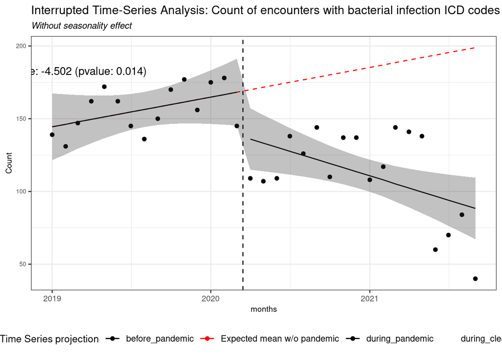

```r
time_series_analysis_plotting(ts_linear_count,
                              patient_count_bacterial_period_bacterial,
                              "count_bacterial_patients",
                              clearance_period = FALSE) +
  labs(title = "Interrupted Time-Series Analysis: Count of encounters with bacterial infection ICD codes",
       subtitle = "Without seasonality effect",
       x = time_period,
       y = "Count")
```

### ITS: patient counts, clearance period, no seasonality effect

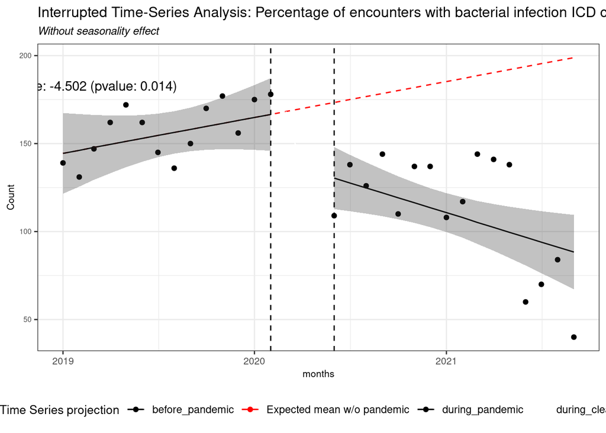

```r
time_series_analysis_plotting(ts_linear_count_clear,
                              patient_count_bacterial_period_bacterial,
                              "count_bacterial_patients",
                              clearance_period = TRUE) +
  labs(title = "Interrupted Time-Series Analysis: Percentage of encounters with bacterial infection ICD codes",
       subtitle = "Without seasonality effect",
       x = time_period,
       y = "Count")
```

### ITS: patient counts, no clearance period, with seasonality effect

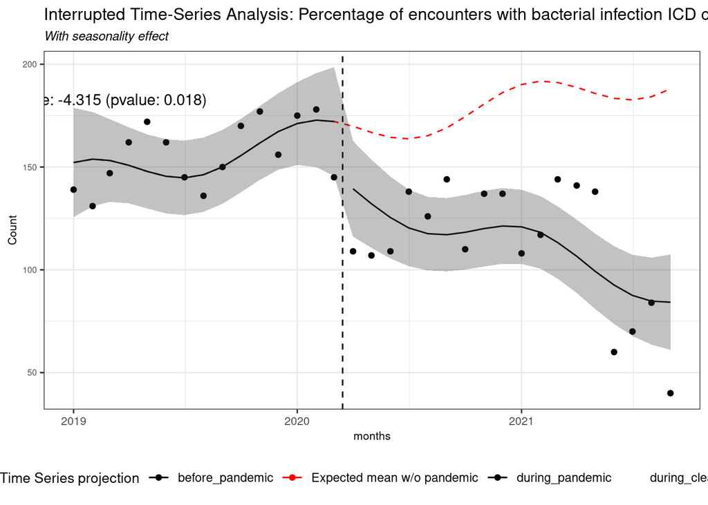

```r
time_series_analysis_plotting(ts_seasonal_count,
                              patient_count_bacterial_period_bacterial,
                              "count_bacterial_patients",
                              clearance_period = FALSE) +
  labs(title = "Interrupted Time-Series Analysis: Percentage of encounters with bacterial infection ICD codes",
       subtitle = "With seasonality effect",
       x = time_period,
       y = "Count")
```

### ITS: patient counts, with clearance period, with seasonality effect

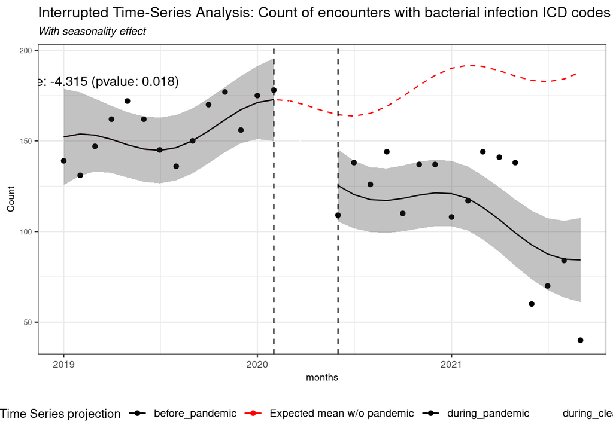

```r
time_series_analysis_plotting(ts_seasonal_count_clear,
                              patient_count_bacterial_period_bacterial,
                              "count_bacterial_patients",
                              clearance_period = TRUE) +
  labs(title = "Interrupted Time-Series Analysis: Count of encounters with bacterial infection ICD codes",
       subtitle = "With seasonality effect",
       x = time_period,
       y = "Count")
```

### ITS: bacterial percentage, no clearance period, no seasonality effect

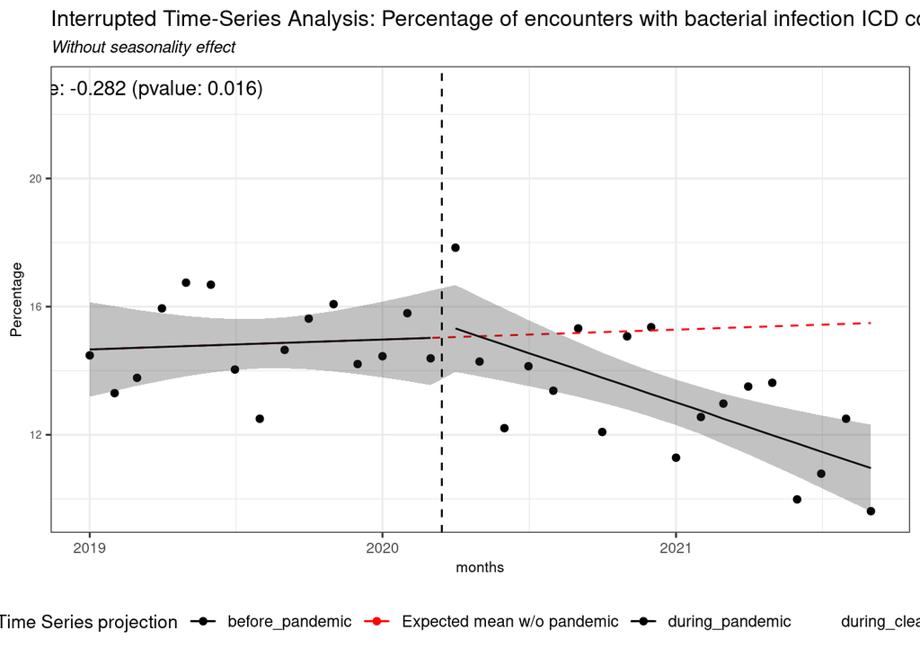

```r
time_series_analysis_plotting(ts_linear_percent,
                              patient_count_bacterial_period_bacterial,
                              "percentage",
                              clearance_period = FALSE) +
  labs(title = "Interrupted Time-Series Analysis: Percentage of encounters with bacterial infection ICD codes",
       subtitle = "Without seasonality effect",
       x = time_period,
       y = "Percentage")
```

### ITS: bacterial percentage, clearance period, no seasonality effect

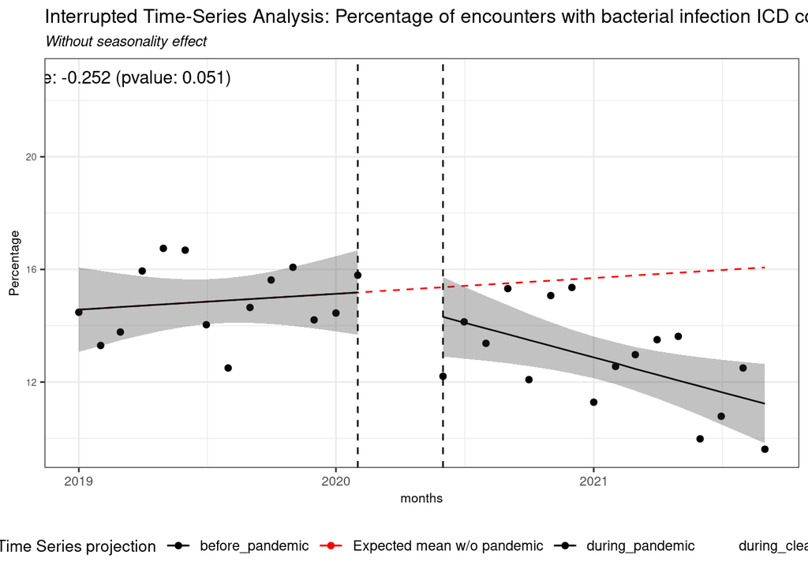

```r
time_series_analysis_plotting(ts_linear_percent_clear,
                              patient_count_bacterial_period_bacterial,
                              "percentage",
                              clearance_period = TRUE) +
  labs(title = "Interrupted Time-Series Analysis: Percentage of encounters with bacterial infection ICD codes",
       subtitle = "Without seasonality effect",
       x = time_period,
       y = "Percentage")
```

### ITS: bacterial percentage, no clearance period, with seasonality effect

[figure not shown]

```r
time_series_analysis_plotting(ts_seasonal_percent,
                              patient_count_bacterial_period_bacterial,
                              "percentage",
                              clearance_period = FALSE) +
  labs(title = "Interrupted Time-Series Analysis: Percentage of encounters with bacterial infection ICD codes",
       subtitle = "Without seasonality effect",
       x = time_period,
       y = "Percentage")
```

### ITS: bacterial percentage, with clearance period, with seasonality effect

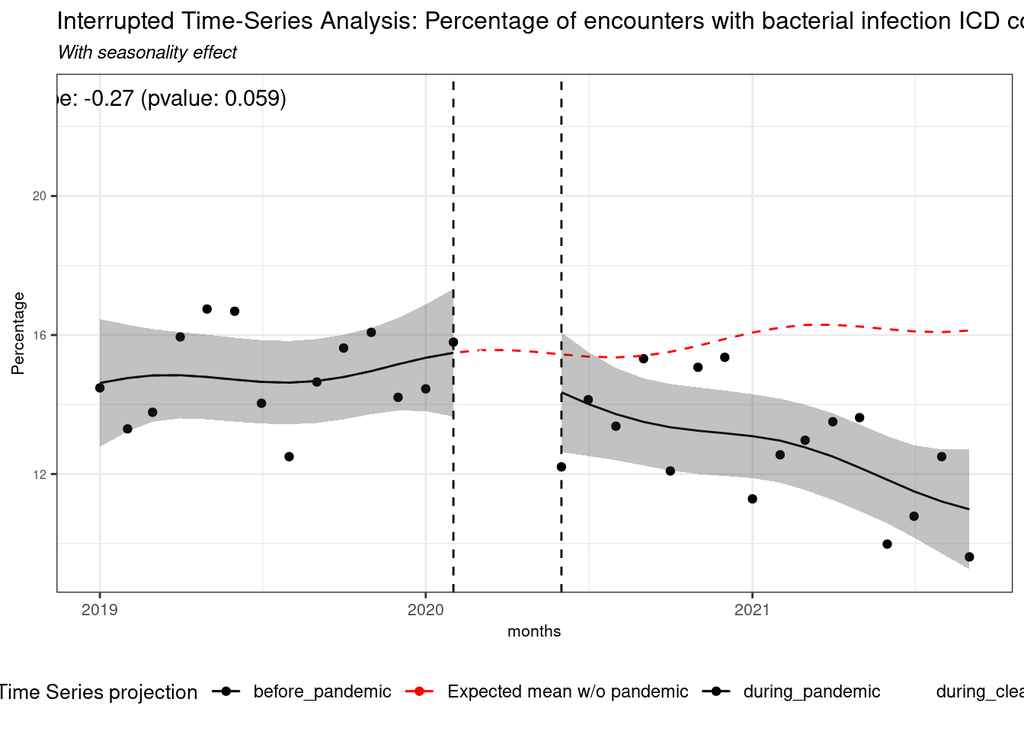

```r
time_series_analysis_plotting(ts_seasonal_percent_clear,
                              patient_count_bacterial_period_bacterial,
                              "percentage",
                              clearance_period = TRUE) +
  labs(title = "Interrupted Time-Series Analysis: Percentage of encounters with bacterial infection ICD codes",
       subtitle = "With seasonality effect",
       x = time_period,
       y = "Percentage")
```

### ITS bootstrap

#### Parametric bootstrap

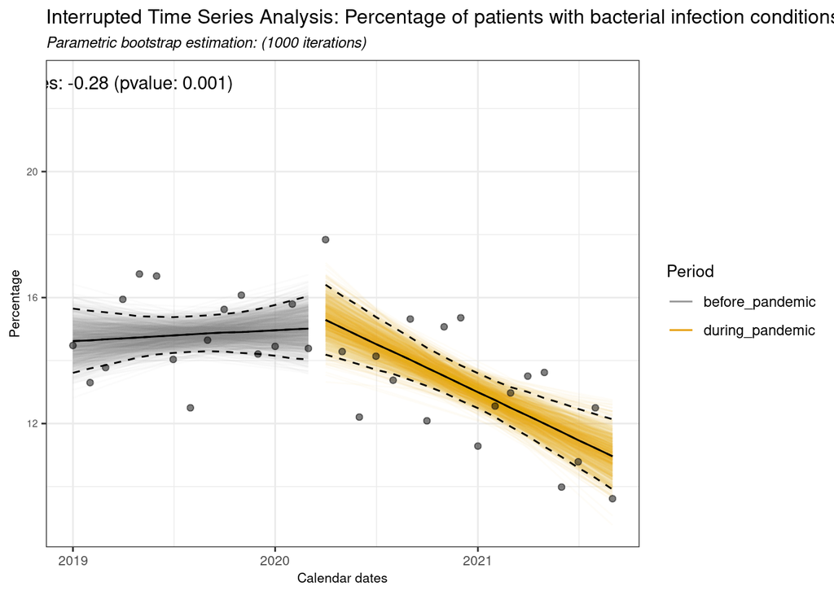

```r
bootstrap_size <- 1000
binom_proportion <- function(n, prob, size) {
  (rbinom(n, size, prob) / size) * 100
}
bootstrapped_timepoints <- mapply(binom_proportion,
                                  n = bootstrap_size,
                                  size = patient_count_bacterial_period_bacterial$count_no_bacterial_patients +
                                    patient_count_bacterial_period_bacterial$count_bacterial_patients,
                                  prob = patient_count_bacterial_period_bacterial$percentage/100)

bootstrapped_sample_list <- vector(mode = "list", length = bootstrap_size)
bootstrapped_coefficients_list <- vector(mode = "list", length = bootstrap_size)
for (iteration in 1:bootstrap_size) {
  df_iteration <- data.frame(period = patient_count_bacterial_period_bacterial$period,
                             time = patient_count_bacterial_period_bacterial$time,
                             percentage = bootstrapped_timepoints[iteration, ])
  ts_linear_percent <- lm(percentage ~ period * time, df_iteration)
  linear_model <- broom::tidy(ts_linear_percent) %>%
    filter(term %in% c("time", "periodduring_pandemic:time"))
  coefficients <- linear_model$estimate
  names(coefficients) <- linear_model$term
  bootstrapped_coefficients_list[[iteration]] <- coefficients
  df_iteration$predicted <- predict(ts_linear_percent)
  df_iteration$time_p <- patient_count_bacterial_period_bacterial$time_p
  bootstrapped_sample_list[[iteration]] <- df_iteration
}

bootstrapped_fitted_df <- bind_rows(bootstrapped_sample_list, .id = "iteration")

quantile_bootstrapped_fitted <- bootstrapped_fitted_df %>%
  group_by(time_p, period) %>%
  summarise("2.5%" = quantile(predicted, 0.025),
            "50%" = quantile(predicted, 0.5),
            "97.5%" = quantile(predicted, 0.975)) %>%
  pivot_longer(cols = c("2.5%", "50%", "97.5%"),
               names_to = "quantiles")
bootstrapped_coefficients_df <- bind_rows(bootstrapped_coefficients_list,
                                          .id = "iteration")

z <-  mean(bootstrapped_coefficients_df[["periodduring_pandemic:time"]]) / sd(bootstrapped_coefficients_df[["periodduring_pandemic:time"]])

pvalue_coeff_interaction <- round(pnorm(abs(z), lower.tail = FALSE) * 2, 3)

plot_annotation <- paste0("Coeffs differences: ",
       round(mean(bootstrapped_coefficients_df[["periodduring_pandemic:time"]]), 2),
       " (pvalue: ",
       pvalue_coeff_interaction,
       ")")

ggplot(bootstrapped_fitted_df, aes(x = time_p, y = predicted, group = interaction(iteration, period))) +
  geom_line(aes(color = period),
            alpha = 0.03) +
  geom_line(data = quantile_bootstrapped_fitted,
            aes(y = value, group = interaction(quantiles, period)),
            linetype = "dashed") +
  geom_line(data = quantile_bootstrapped_fitted[quantile_bootstrapped_fitted$quantiles == "50%", ],
            aes(y = value, group = period)) +
  geom_point(data = patient_count_bacterial_period_bacterial,
             aes(y = percentage),
             alpha = 0.5) +
  scale_colour_manual(values = cbPalette) +
  guides(color = guide_legend(override.aes = list(alpha = 1))) +
  annotate("text",
           x = as.Date("2019-01-01"),
           y = max(patient_count_bacterial_period_bacterial[["percentage"]]) + 5,
           label = plot_annotation) +
  labs(title = "Interrupted Time Series Analysis: Percentage of patients with bacterial infection conditions",
       subtitle = "Parametric bootstrap estimation: (1000 iterations)",
       x = "Calendar dates",
       y = "Percentage",
       color = "Period")
```

## bacterial infection conditions aggregating by subcategories

### New admissions: count

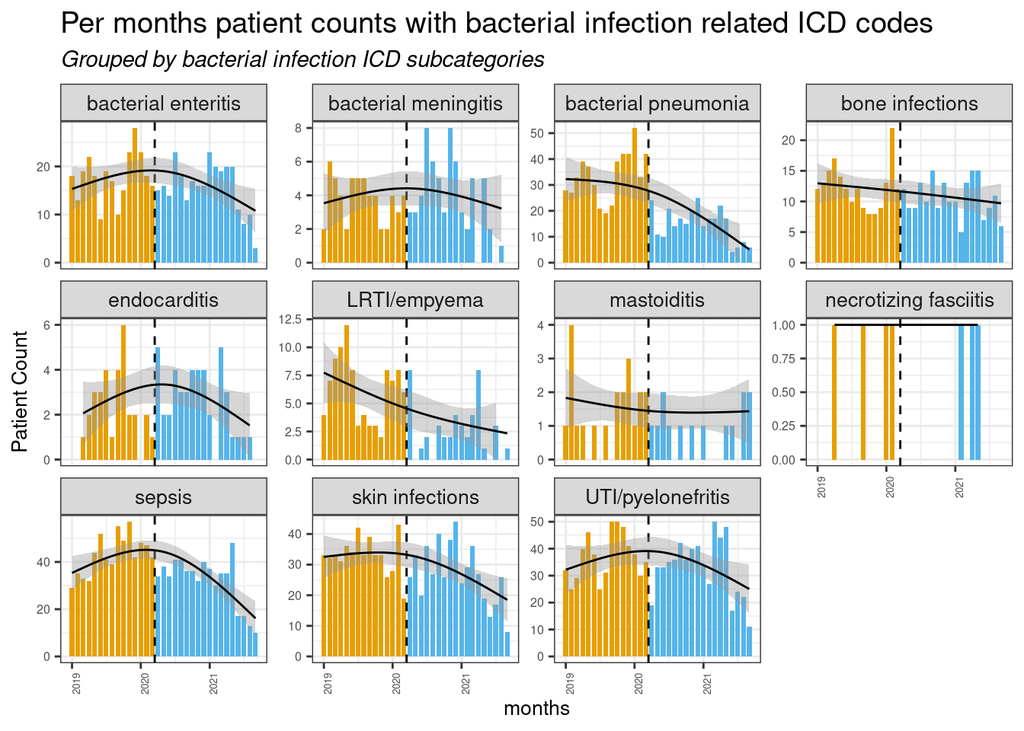

```r
count_disorder_group <- all_codes_bacterial %>%
  filter(date < end_date_plots &
         date >= start_date_plots ) %>%
    group_by( time_p, disorder_group ) %>%
  summarise(count_dg =  ifelse(n_distinct(patient_num) > obfuscation | isFALSE(obfuscation),
                               n_distinct(patient_num),
                               0.5)) %>%
  mutate( period = ifelse( time_p < pandemic_start_date,
                           "before_pandemic",
                           "during_pandemic")
  )
dg <- count_disorder_group %>%
  ggplot(aes(x = time_p, y= count_dg, fill = period, group = disorder_group )) +
  geom_bar(stat = "identity")+
  geom_vline(xintercept = as.Date(pandemic_start_date),
             linetype = "dashed") +
  geom_smooth(method = "lm", formula = y ~ splines::ns(x, 2), se= TRUE, aes(colour=period), colour= "black", size = 0.5) +
  labs(x = time_period,
       y = "Patient Count",
       title = paste0("Per ", time_period, " patient counts with bacterial infection related ICD codes"),
       subtitle = "Grouped by bacterial infection ICD subcategories") +
  ylim(0, NA) +
  facet_wrap(. ~ disorder_group, scales = "free_y") +
  theme(strip.text.x = element_text(size = 10),
        axis.text.x = element_text(size = 5, angle = 90),
        axis.text.y = element_text(size = 6),
        axis.title.x = element_text(size = 10),
        axis.title.y = element_text(size = 10),
        title = element_text(size = 12),
        plot.subtitle = element_text(size = 11),
        legend.position = "none") +
  scale_fill_manual(values = cbPalette[-1])

dg
```

### New admissions: percentage

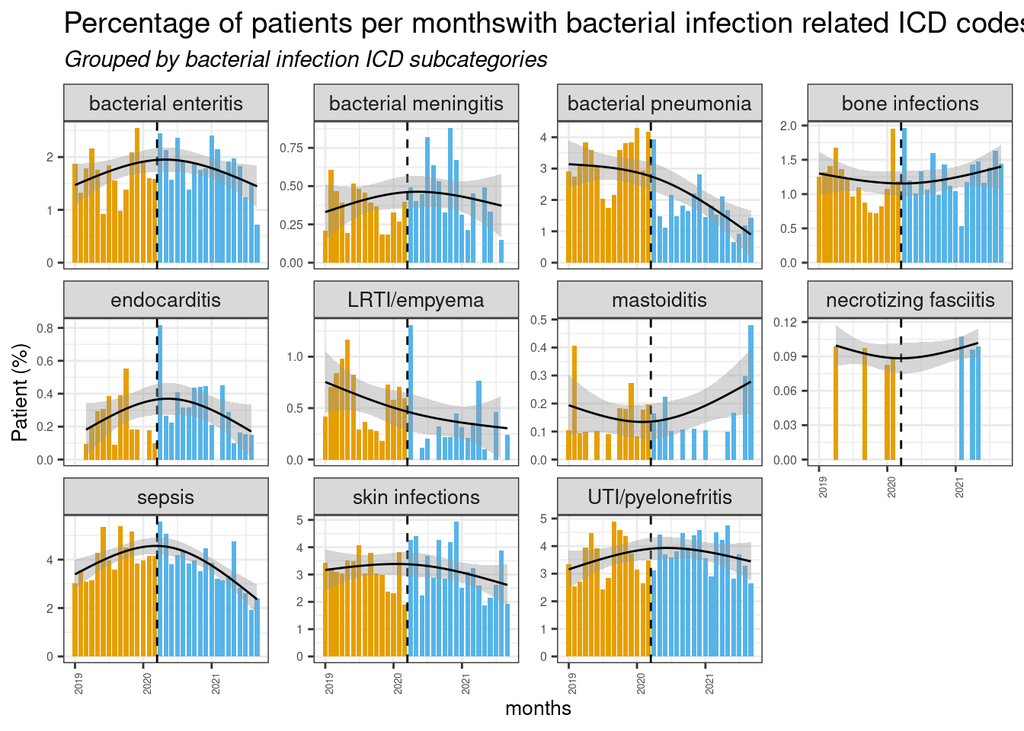

```r
# estimate the counts
count_icd_all <- all_codes_desc %>%
  filter(date < end_date_plots &
         date >= start_date_plots ) %>%
    group_by( time_p ) %>%
  summarise(count_icd =  ifelse(n_distinct(patient_num) > obfuscation | isFALSE(obfuscation),
                               n_distinct(patient_num),
                               0.5)) %>%
  mutate( period = ifelse( time_p < pandemic_start_date,
                           "before_pandemic",
                           "during_pandemic")
  )


# join the total with the disorder group count to estimate the percentage
perc_disorder_group <- count_icd_all %>%
  left_join(count_disorder_group,
            by = c("time_p", "period")) %>%
  replace_na(list(count_dg = 0))

perc_disorder_group$percentage_dg <- 100*perc_disorder_group$count_dg / perc_disorder_group$count_icd

dgPerc <- perc_disorder_group %>%
  ggplot(aes(x = time_p, y= percentage_dg, fill = period, group = disorder_group )) +
  geom_bar(stat = "identity")+
  geom_vline(xintercept = as.Date(pandemic_start_date),
             linetype = "dashed") +
  geom_smooth(method = "lm", formula = y ~ splines::ns(x, 2), se= TRUE, aes(colour=period), colour= "black", size = 0.5) +
  labs(x = time_period,
       y = "Patient (%)",
       title = paste0("Percentage of patients per ", time_period,"with bacterial infection related ICD codes"),
       subtitle = "Grouped by bacterial infection ICD subcategories") +
  ylim(0, NA) +
  facet_wrap(. ~ disorder_group, scales = "free_y") +
  theme(strip.text.x = element_text(size = 10),
        axis.text.x = element_text(size = 5, angle = 90),
        axis.text.y = element_text(size = 6),
        axis.title.x = element_text(size = 10),
        axis.title.y = element_text(size = 10),
        title = element_text(size = 12),
        plot.subtitle = element_text(size = 11),
        legend.position = "none") +
  scale_fill_manual(values = cbPalette[-1])

dgPerc
```

## bacterial infection conditions, dichotomized on patients’ sex

### Count

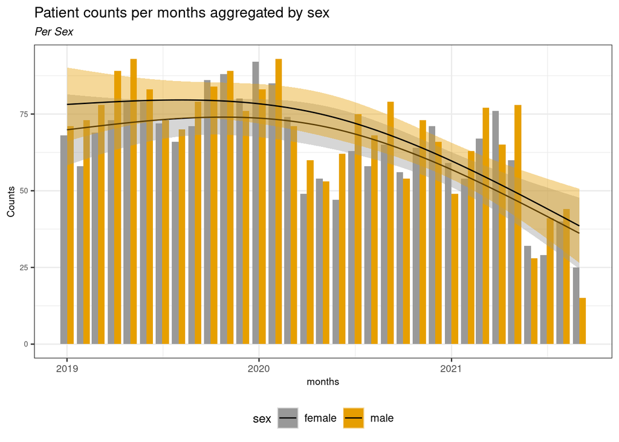

```r
# counts per time period and sex
patients_hospitalized_agg_sex <- all_codes_bacterial %>%
  filter(date < end_date_plots &
         date >= start_date_plots &
           sex %in% c("female", "male")) %>%
    group_by( time_p, sex ) %>%
  summarise(count_sex =  ifelse(n_distinct(patient_num) > obfuscation | isFALSE(obfuscation),
                               n_distinct(patient_num),
                               0.5))
patients_hospitalized_agg_sex %>%
  ggplot(aes(x = time_p, y = count_sex, fill = sex)) +
  geom_bar(stat="identity", position = "dodge")+
  scale_fill_manual(values = cbPalette) +
  labs(y = "Counts",
       x = time_period,
       title = paste0("Patient counts per ", time_period, " aggregated by sex"),
       subtitle = "Per Sex") +
  theme(legend.position = "bottom") +
  geom_smooth(method = "lm", formula = y ~ splines::ns(x, 2), se = TRUE, aes(colour=sex), colour= "black", size = 0.5)
```

### Percentage

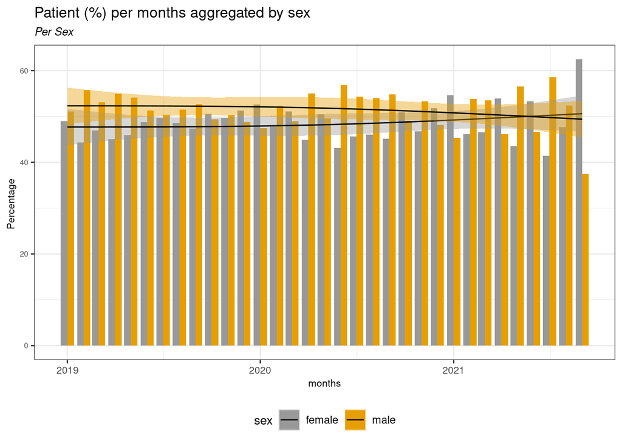

```r
##percentage
total_patients_bacterial <- all_codes_bacterial %>%
  filter(date < end_date_plots &
         date >= start_date_plots ) %>%
    group_by( time_p ) %>%
  summarise(count =  ifelse(n_distinct(patient_num) > obfuscation | isFALSE(obfuscation),
                               n_distinct(patient_num),
                               0.5))

patients_hospitalized_agg_sex_perc <- total_patients_bacterial %>%
  left_join( patients_hospitalized_agg_sex, by = c("time_p")) %>%
  replace_na(list(count_sex = 0))

patients_hospitalized_agg_sex_perc$percentage <- 100*patients_hospitalized_agg_sex_perc$count_sex/patients_hospitalized_agg_sex_perc$count

patients_hospitalized_agg_sex_perc %>%
  ggplot(aes(x = time_p, y = percentage, fill = sex)) +
  geom_bar(stat="identity", position = "dodge")+
  scale_fill_manual(values = cbPalette) +
  labs(y = "Percentage ",
       x = time_period,
       title = paste0("Patient (%) per ", time_period," aggregated by sex"),
       subtitle = "Per Sex") +
  theme(legend.position = "bottom") +
  geom_smooth(method = "lm", formula = y ~ splines::ns(x, 2), se = TRUE, aes(colour=sex), colour= "black", size = 0.5)
```